# Chap5.7-5.8

Mijeong Kim

```r
library(tsibble)
library(tsibbledata)
library(tibble)
library(dplyr)
library(knitr)
library(ggplot2)
library(fpp3)
library(fpp2)
library(seasonal)
library(feasts)
```

## 5.7 Forecasting with decomposition

시계열 분해(Chapter 3)는 **예측을 위한 유용한 전처리 과정**이 될 수 있음.  
시계열은 **가법(additive) 또는 승법(multiplicative) 방식으로 분해 가능**.

#### 1. 가법 분해(Additive Decomposition)

$$y_t = \hat{S}_t + \hat{A}_t$$

여기서,

- $\hat{S}_t$ : 계절 성분 (seasonal component)
- $\hat{A}_t$ : 계절 조정 성분 (seasonally adjusted component)
  - $\hat{A}_t = \hat{T}_t + \hat{R}_t$
  - $\hat{T}_t$ : 추세 성분 (trend)
  - $\hat{R}_t$ : 불규칙 성분 (remainder)

#### 2. 승법 분해(Multiplicative Decomposition)

$$y_t = \hat{S}_t \hat{A}_t$$

여기서,

- $\hat{A}_t = \hat{T}_t \hat{R}_t$  
  (계절 조정 성분은 추세와 불규칙 성분의 곱으로 표현됨)

#### 분해된 시계열의 예측 방법

1. **계절 성분( $\hat{S}_t$ ) 예측**
   - 계절 성분은 보통 일정하거나 **천천히 변화한다고 가정**
   - 따라서, **마지막 1년간의 계절 성분을 그대로 사용**
   - 즉, **계절적 나이브(Seasonal Naïve) 방법 사용**
2. **계절 조정 성분( $\hat{A}_t$ ) 예측**
   - **비계절적(non-seasonal) 예측 방법 사용 가능**
   - 예측 방법 예시:
     - **드리프트(Drift) 방법**
     - **Holt’s 방법(Chapter 8)**
     - **비계절적 ARIMA 모델(Chapter 9)**

### Example: Employment in the US retail sector

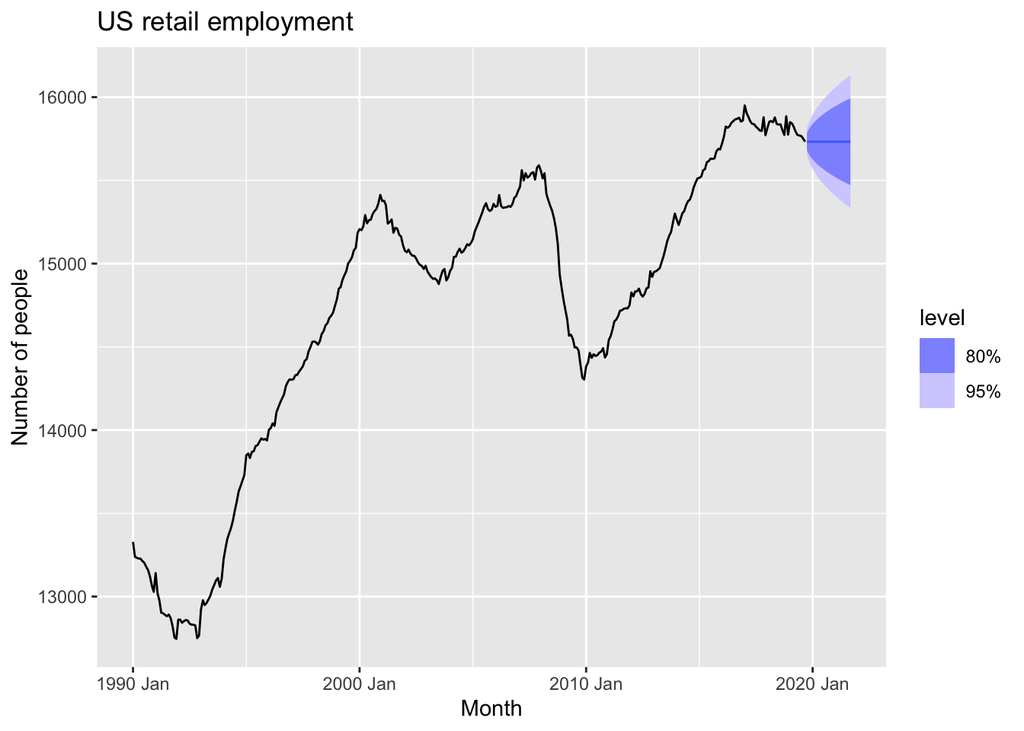

```r
us_retail_employment <- us_employment |>
  filter(year(Month) >= 1990, Title == "Retail Trade")
dcmp <- us_retail_employment |>
  model(STL(Employed ~ trend(window = 7), robust = TRUE)) |>
  components() |>
  select(-.model)
dcmp |>
  model(NAIVE(season_adjust)) |>
  forecast() |>
  autoplot(dcmp) +
  labs(y = "Number of people",
       title = "US retail employment")
```

- 그림 5.18에서는 계절 조정된(Seasonally Adjusted) 미국 소매업 고용 데이터에 대해 나이브(naïve) 예측을 수행한 결과를 보여줌.
- 그런 다음, **계절적 나이브(Seasonal Naïve) 예측을 이용하여 계절 성분을 다시 추가(“재계절화”, reseasonalising)**함.

decomposition_model() 함수의 활용 * decomposition_model() 함수를 사용하면 가법 분해(Additive Decomposition)를 활용한 예측을 쉽게 수행 가능. * 각 분해된 성분을 개별적으로 예측할 수 있도록 지원. * 계절 성분은 기본적으로 SNAIVE()를 사용하여 자동 예측, 다른 모델을 지정할 수도 있음. * 최종적으로 자동으로 “재계절화(reseasonalising)” 수행, 원래 데이터에 대한 예측을 생성.

그림 5.19에서는 이 과정을 통해 생성된 최종 예측 결과를 보여줌.

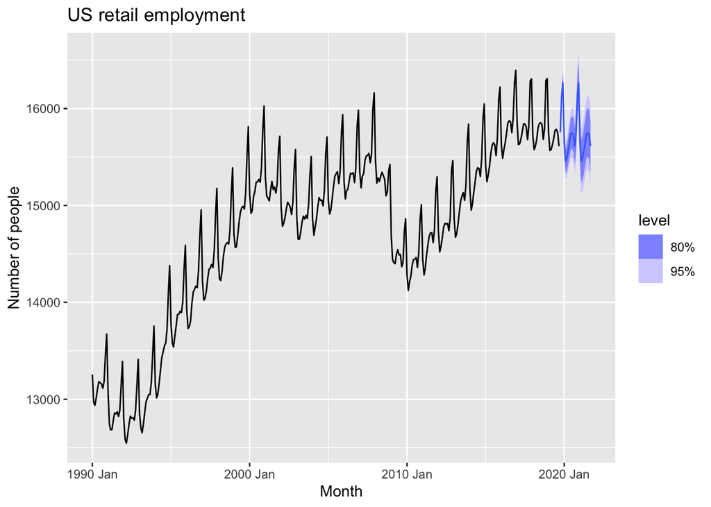

```r
fit_dcmp <- us_retail_employment |>
  model(stlf = decomposition_model(
    STL(Employed ~ trend(window = 7), robust = TRUE),
    NAIVE(season_adjust)
  ))
fit_dcmp |>
  forecast() |>
  autoplot(us_retail_employment)+
  labs(y = "Number of people",
       title = "US retail employment")
```

그래프에 표시된 예측 구간은 점 예측과 동일한 방식으로 구성됨.

- 즉, **계절 조정된 데이터의 예측 구간의 상한 및 하한을 “재계절화(reseasonalising)”**하여 최종 예측 구간을 생성.
- 이를 위해 계절 성분의 예측값을 추가함.

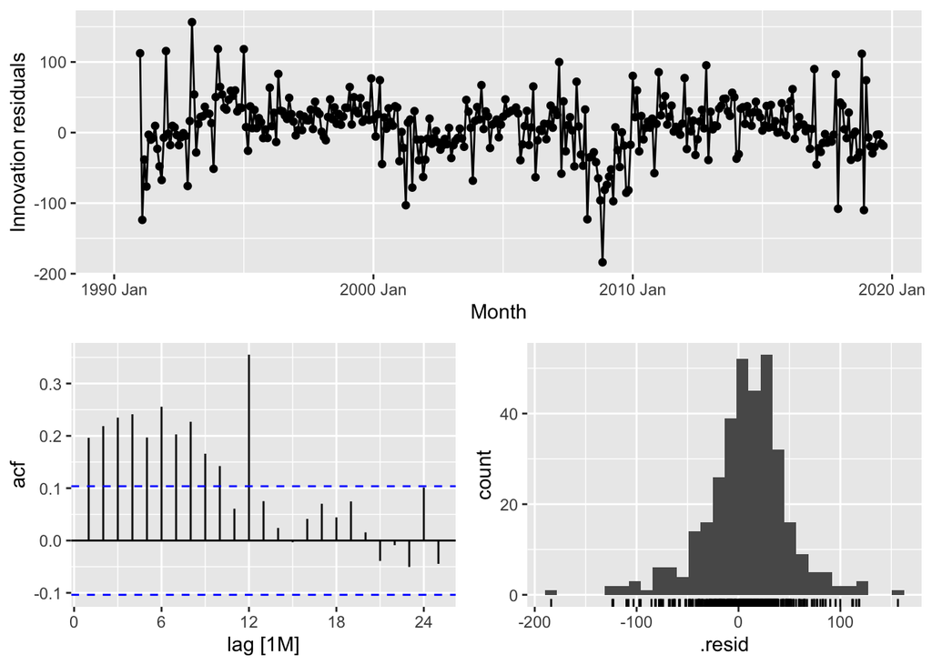

```r
fit_dcmp |> gg_tsresiduals()
```

그림 5.20에서는 잔차의 ACF(자기상관 함수)를 보여줌.

- 유의미한 자기상관(autocorrelation)이 존재함.
- 이는 나이브 방법이 계절 조정된 데이터의 변화하는 추세를 제대로 반영하지 못했기 때문임.

## 5.8 Evaluating point forecast accuracy

### Training and test sets

예측 모델의 정확성은 모델을 학습하는 데 사용되지 않은 새로운 데이터를 통해 평가해야 한다.

- Training data (in-sample data): 모델의 파라미터를 추정하는 데 사용됨.
- Test data (hold-out set, out-of-sample data): 모델의 예측 성능을 평가하는 데 활용됨. Test data는 모델 학습에 사용되지 않으므로, 모델이 새로운 데이터에서 얼마나 잘 작동할지를 평가하는 데 유용함. 전체 샘플의 약 20% 정도가 일반적이나, 예측하고자 하는 기간에 따라 달라짐.

다음 사항을 유의해야 한다.

- 훈련 데이터에서 잘 맞는 모델이 반드시 좋은 예측을 제공하는 것은 아니다.
- 충분한 파라미터를 사용하면 언제든지 완벽한 피팅이 가능하지만, 이는 일반화 성능을 저하시킨다.
- 과적합(overfitting)된 모델은 데이터를 제대로 분석하지 못한 모델만큼이나 나쁜 결과를 초래할 수 있다.

### Functions to subset a time series

filter() 함수는 시계열 데이터의 일부를 추출할 때 유용하다. 특히 학습(training) 및 테스트(test) 세트를 생성할 때 필요하다. 데이터를 평가 세트로 분할할 때, 데이터의 인덱스를 필터링하는 것이 특히 유용하다.

```r
aus_production |> filter(year(Quarter) >= 1995)
```

```
## # A tsibble: 62 x 7 [1Q]
##    Quarter  Beer Tobacco Bricks Cement Electricity   Gas
##      <qtr> <dbl>   <dbl>  <dbl>  <dbl>       <dbl> <dbl>
##  1 1995 Q1   426    4714    430   1626       41768   131
##  2 1995 Q2   408    3939    457   1703       43686   167
##  3 1995 Q3   416    6137    417   1733       46022   181
##  4 1995 Q4   520    4739    370   1545       42800   145
##  5 1996 Q1   409    4275    310   1526       43661   133
##  6 1996 Q2   398    5239    358   1593       44707   162
##  7 1996 Q3   398    6293    379   1706       46326   184
##  8 1996 Q4   507    5575    369   1699       43346   146
##  9 1997 Q1   432    4802    330   1511       43938   135
## 10 1997 Q2   398    5523    390   1785       45828   171
## # ℹ 52 more rows
```

또는 다음과 같이 입력해도 된다.

```r
aus_production |> filter_index("1995 Q1" ~ .)
```

```
## # A tsibble: 62 x 7 [1Q]
##    Quarter  Beer Tobacco Bricks Cement Electricity   Gas
##      <qtr> <dbl>   <dbl>  <dbl>  <dbl>       <dbl> <dbl>
##  1 1995 Q1   426    4714    430   1626       41768   131
##  2 1995 Q2   408    3939    457   1703       43686   167
##  3 1995 Q3   416    6137    417   1733       46022   181
##  4 1995 Q4   520    4739    370   1545       42800   145
##  5 1996 Q1   409    4275    310   1526       43661   133
##  6 1996 Q2   398    5239    358   1593       44707   162
##  7 1996 Q3   398    6293    379   1706       46326   184
##  8 1996 Q4   507    5575    369   1699       43346   146
##  9 1997 Q1   432    4802    330   1511       43938   135
## 10 1997 Q2   398    5523    390   1785       45828   171
## # ℹ 52 more rows
```

또 다른 유용한 함수는 slice()이다. 이 함수는 각 그룹에서 인덱스를 사용하여 하위 집합을 선택할 수 있도록 한다.

```r
aus_production |>
  slice(n()-19:0)
```

```
## # A tsibble: 20 x 7 [1Q]
##    Quarter  Beer Tobacco Bricks Cement Electricity   Gas
##      <qtr> <dbl>   <dbl>  <dbl>  <dbl>       <dbl> <dbl>
##  1 2005 Q3   408      NA     NA   2340       56043   221
##  2 2005 Q4   482      NA     NA   2265       54992   180
##  3 2006 Q1   438      NA     NA   2027       57112   171
##  4 2006 Q2   386      NA     NA   2278       57157   224
##  5 2006 Q3   405      NA     NA   2427       58400   233
##  6 2006 Q4   491      NA     NA   2451       56249   192
##  7 2007 Q1   427      NA     NA   2140       56244   187
##  8 2007 Q2   383      NA     NA   2362       55036   234
##  9 2007 Q3   394      NA     NA   2536       59806   245
## 10 2007 Q4   473      NA     NA   2562       56411   205
## 11 2008 Q1   420      NA     NA   2183       59118   194
## 12 2008 Q2   390      NA     NA   2558       56660   229
## 13 2008 Q3   410      NA     NA   2612       64067   249
## 14 2008 Q4   488      NA     NA   2373       59045   203
## 15 2009 Q1   415      NA     NA   1963       58368   196
## 16 2009 Q2   398      NA     NA   2160       57471   238
## 17 2009 Q3   419      NA     NA   2325       58394   252
## 18 2009 Q4   488      NA     NA   2273       57336   210
## 19 2010 Q1   414      NA     NA   1904       58309   205
## 20 2010 Q2   374      NA     NA   2401       58041   236
```

마지막 20개의 관측값(5년)을 추출한다. **slice**는 그룹과 함께 사용할 수도 있어, 각 키(key)별로 관측값을 부분 집합(subset)으로 추출할 수 있다.

```r
aus_retail |>
  group_by(State, Industry) |>
  slice(1:12)
```

```
## # A tsibble: 1,824 x 5 [1M]
## # Key:       State, Industry [152]
## # Groups:    State, Industry [152]
##    State                        Industry           `Series ID`    Month Turnover
##    <chr>                        <chr>              <chr>          <mth>    <dbl>
##  1 Australian Capital Territory Cafes, restaurant… A3349849A   1982 Apr      4.4
##  2 Australian Capital Territory Cafes, restaurant… A3349849A   1982 May      3.4
##  3 Australian Capital Territory Cafes, restaurant… A3349849A   1982 Jun      3.6
##  4 Australian Capital Territory Cafes, restaurant… A3349849A   1982 Jul      4
##  5 Australian Capital Territory Cafes, restaurant… A3349849A   1982 Aug      3.6
##  6 Australian Capital Territory Cafes, restaurant… A3349849A   1982 Sep      4.2
##  7 Australian Capital Territory Cafes, restaurant… A3349849A   1982 Oct      4.8
##  8 Australian Capital Territory Cafes, restaurant… A3349849A   1982 Nov      5.4
##  9 Australian Capital Territory Cafes, restaurant… A3349849A   1982 Dec      6.9
## 10 Australian Capital Territory Cafes, restaurant… A3349849A   1983 Jan      3.8
## # ℹ 1,814 more rows
```

### 예측 오차(Forecast Error)

예측 오차(forecast error)는 실제 관측값과 예측값의 차이를 의미한다. 여기서 “오차(error)”는 실수를 의미하는 것이 아니라, 관측값의 예측 불가능한 부분을 의미한다. 이는 다음과 같이 표현할 수 있다:

$$e_{T+h} = y_{T+h} - \hat{y}_{T+h | T}$$

여기서 학습 데이터는 $\{y_1, ..., y_T\}$이고, 테스트 데이터는 $\{y_{T+1}, y_{T+2}, ...\}$이다.

#### 예측 오차와 잔차의 차이

예측 오차는 **잔차(residuals)**와 두 가지 측면에서 다르다.

1. **계산 방식**: 잔차는 **훈련 세트(training set)**에서 계산되지만, 예측 오차는 **테스트 세트(test set)**에서 계산된다.
2. **예측 유형**: 잔차는 **단일 스텝(one-step) 예측**을 기반으로 하지만, 예측 오차는 **다중 스텝(multi-step) 예측**을 포함할 수 있다.

#### 예측 정확도 평가

예측 정확도는 이러한 예측 오차를 다양한 방식으로 요약하여 측정할 수 있다. 일반적인 방법으로는 다음과 같은 지표가 사용된다.

- **평균 절대 오차 (MAE, Mean Absolute Error)**
  $$MAE = \frac{1}{n} \sum_{i=1}^{n} |e_i|$$
- **평균 제곱 오차 (MSE, Mean Squared Error)**
  $$MSE = \frac{1}{n} \sum_{i=1}^{n} e_i^2$$
- **평균 절대 백분율 오차 (MAPE, Mean Absolute Percentage Error)**
  $$MAPE = \frac{100}{n} \sum_{i=1}^{n} \left| \frac{e_i}{y_i} \right|$$

이러한 지표를 활용하여 예측 모델의 성능을 평가할 수 있다.

### Scale-dependent Errors

예측 오차는 원래 데이터와 동일한 단위를 가지므로,  
오차 값 $e_t$ 만을 사용하는 정확도 측정 방법은  
다른 단위를 사용하는 시계열 간 비교에 적합하지 않다.

가장 널리 사용되는 규모 의존적 지표는 절대 오차 및 제곱 오차를 기반으로 한다.

- **평균 절대 오차 (MAE, Mean Absolute Error)**
  $$MAE = \text{mean}(|e_t|)$$
- **평균 제곱근 오차 (RMSE, Root Mean Squared Error)**
  $$RMSE = \sqrt{\text{mean}(e_t^2)}$$

MAE는 이해하기 쉽고 계산이 간단하여 널리 사용되며,  
MAE를 최소화하면 **중앙값(median)**을 예측하는 경향이 있다.  
반면, RMSE를 최소화하면 **평균(mean)**을 예측하는 경향이 있으며,  
해석이 어려운 단점에도 불구하고 널리 활용된다.

### 백분율 오차 (Percentage Errors)

백분율 오차는 단위가 없는(unit-free) 지표이므로  
서로 다른 데이터 세트 간 예측 성능을 비교할 때 자주 사용된다.

- **평균 절대 백분율 오차 (MAPE, Mean Absolute Percentage Error)**
  $$MAPE = \text{mean}(|p_t|)$$
  여기서,
  $$p_t = 100 \times \frac{e_t}{y_t}$$

백분율 오차는 다음과 같은 단점이 있다. 1. $y_t = 0$일 경우 무한대가 되거나 정의되지 않는다. 2. $y_t$ 값이 0에 가까우면 극단적인 값이 발생할 수 있다. 3. 섭씨(Celsius)나 화씨(Fahrenheit) 온도처럼 의미 있는 영점(Zero Point)이 없는 데이터에는 적절하지 않다.

**대칭적 MAPE (sMAPE)**는 이를 보완하기 위해 제안되었으나,  
$y_t$가 0에 가까우면 불안정한 계산이 발생하며,  
Hyndman & Koehler (2006)에 의해 사용이 권장되지 않는다.

- **대칭적 MAPE (sMAPE)**
  $$sMAPE = \text{mean} \left( 200 \times \frac{|y_t - \hat{y_t}|}{y_t +
  \hat{y_t}} \right)$$

### Scaled Errors

Hyndman & Koehler (2006)은 서로 다른 단위의 시계열 간 비교를 위해  
백분율 오차 대신 **규모 조정 오차(scaled errors)**를 제안하였다.

비계절성 시계열(non-seasonal)에서는 단순 예측법의 MAE를 기준으로 조정한다.

- **비계절성 시계열에서의 규모 조정 오차**
  $$q_j = \frac{e_j}{\frac{1}{T-1} \sum_{t=2}^{T} |y_t - y_{t-1}|}$$
- **계절성 시계열에서의 규모 조정 오차**
  $$q_j = \frac{e_j}{\frac{1}{T-m} \sum_{t=m+1}^{T} |y_t - y_{t-m}|}$$
- **평균 절대 규모 조정 오차 (MASE, Mean Absolute Scaled Error)**
  $$MASE = \text{mean}(|q_j|)$$
- **평균 제곱근 규모 조정 오차 (RMSSE, Root Mean Squared Scaled Error)**
  $$RMSSE = \sqrt{\text{mean}(q_j^2)}$$

위의 방법을 사용하면 서로 다른 단위를 가지는 시계열 데이터를 보다 공정하게 비교할 수 있다.

### Examples

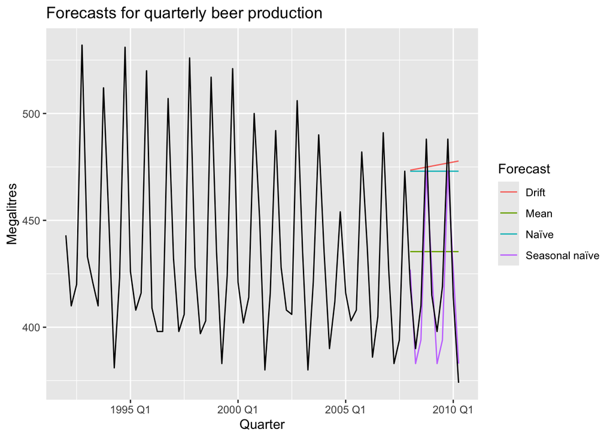

```r
recent_production <- aus_production |>
  filter(year(Quarter) >= 1992)
beer_train <- recent_production |>
  filter(year(Quarter) <= 2007)

beer_fit <- beer_train |>
  model(
    Mean = MEAN(Beer),
    `Naïve` = NAIVE(Beer),
    `Seasonal naïve` = SNAIVE(Beer),
    Drift = RW(Beer ~ drift())
  )

beer_fc <- beer_fit |>
  forecast(h = 10)

beer_fc |>
  autoplot(
    aus_production |> filter(year(Quarter) >= 1992),
    level = NULL
  ) +
  labs(
    y = "Megalitres",
    title = "Forecasts for quarterly beer production"
  ) +
  guides(colour = guide_legend(title = "Forecast"))
```

Figure 5.21: Forecasts of Australian quarterly beer production using data up to the end of 2007.

그림 5.21은 2007년 말까지의 데이터를 사용하여 분기별 호주 맥주 생산량에 적용된 네 가지 예측 방법을 보여준다. 또한 2008년부터 2010년까지의 실제 값도 함께 표시되어 있다. 우리는 이 기간 동안의 예측 정확도 측정값을 계산한다.

```r
accuracy(beer_fc, recent_production)
```

```
## # A tibble: 4 × 10
##   .model         .type    ME  RMSE   MAE    MPE  MAPE  MASE RMSSE    ACF1
##   <chr>          <chr> <dbl> <dbl> <dbl>  <dbl> <dbl> <dbl> <dbl>   <dbl>
## 1 Drift          Test  -54.0  64.9  58.9 -13.6  14.6  4.12  3.87  -0.0741
## 2 Mean           Test  -13.8  38.4  34.8  -3.97  8.28 2.44  2.29  -0.0691
## 3 Naïve          Test  -51.4  62.7  57.4 -13.0  14.2  4.01  3.74  -0.0691
## 4 Seasonal naïve Test    5.2  14.3  13.4   1.15  3.17 0.937 0.853  0.132
```

accuracy() 함수는 예측과 일치하도록 데이터(예제에서는 recent_production의 데이터)에서 적절한 기간을 자동으로 추출하여 다양한 정확도 측정값을 계산한다.

그래프를 보면, **계절적 순진 예측(Seasonal Naïve Method)**이 이 데이터에 가장 적합한 방법임이 명확하다. 하지만 향후 더 나은 방법이 있을 수도 있다. 일반적으로, 서로 다른 정확도 측정값이 최적의 예측 방법에 대해 상이한 결과를 도출할 수 있지만, 이 경우 네 가지 방법 중 계절적 순진 예측 방법이 가장 우수한 것으로 나타났다.

비계절성 예측의 예로 Google 주가를 고려할 수 있다. 다음 그래프는 2015년 종가 데이터를 기반으로, 2016년 1월 예측값을 세 가지 방법으로 계산한 결과를 보여준다.

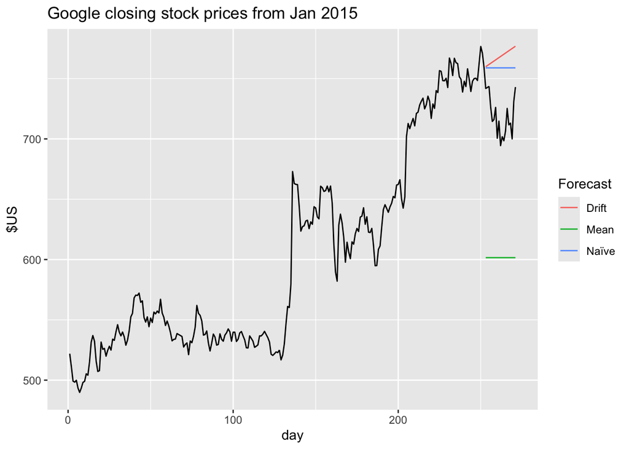

```r
google_stock <- gafa_stock |>
  filter(Symbol == "GOOG", year(Date) >= 2015) |>
  mutate(day = row_number()) |>
  update_tsibble(index = day, regular = TRUE)
# Filter the year of interest
google_2015 <- google_stock |> filter(year(Date) == 2015)


google_jan_2016 <- google_stock |>
  filter(yearmonth(Date) == yearmonth("2016 Jan"))

google_fit <- google_2015 |>
  model(
    Mean = MEAN(Close),
    `Naïve` = NAIVE(Close),
    Drift = RW(Close ~ drift())
  )

google_fc <- google_fit |>
  forecast(google_jan_2016)
google_fc |>
  autoplot(bind_rows(google_2015, google_jan_2016),
    level = NULL) +
  labs(y = "$US",
       title = "Google closing stock prices from Jan 2015") +
  guides(colour = guide_legend(title = "Forecast"))
```

Figure 5.22: Forecasts of the Google stock price for Jan 2016.

```r
accuracy(google_fc, google_stock)
```

```
## # A tibble: 3 × 11
##   .model Symbol .type    ME  RMSE   MAE   MPE  MAPE  MASE RMSSE  ACF1
##   <chr>  <chr>  <chr> <dbl> <dbl> <dbl> <dbl> <dbl> <dbl> <dbl> <dbl>
## 1 Drift  GOOG   Test  -49.8  53.1  49.8 -6.99  6.99  6.99  4.74 0.604
## 2 Mean   GOOG   Test  117.  118.  117.  16.2  16.2  16.4  10.5  0.496
## 3 Naïve  GOOG   Test  -40.4  43.4  40.4 -5.67  5.67  5.67  3.88 0.496
```

여기서 최적의 방법은 **Naïve Method**이며, 어떤 정확도 측정값을 사용하더라도 동일한 결과가 나온다.